# Fitting A Linear Model

## Setup

```r
library(tidyverse)
library(patchwork)
library(ggplot2)

# Change this to your week 4 folder
#setwd(r"(C:/Users/Valentin/Documents/GIT_REPS/TUHH/Applied-Statistics/week04)")
setwd(r"(C:\AsAd\Python_Related\Applied_Statistics\AppliedStatistics\week04)")
```

Note that when saving images, do it with this ratio to fit perfectly into the TUHH template:

width = 8.74, height = 5.11

## Import Data

```r
video_game_data <- read.csv("Video_Games_Sales_as_at_22_Dec_2016.csv")

clean_data <- video_game_data |>
  select(User_Score, Critic_Score, Year_of_Release, Global_Sales) |>
  mutate(User_Score = as.numeric(User_Score)*10) |>
  mutate(Year_of_Release = as.numeric(Year_of_Release)) |>
  select(where(is.numeric)) |>
  drop_na()

# Row index of the game with max sales
max_index <- which.max(clean_data$Global_Sales)

# View the entire row
clean_data[max_index, ]
```

|  | User_Score | Critic_Score | Year_of_Release | Global_Sales |
| --- | --- | --- | --- | --- |
| 1 | 80 | 76 | 2006 | 82.53 |

```r
print(length(clean_data$User_Score))
```

```
[1] 6894
```

## Data Visualization

filtering N/A:

$$\begin{align*}
N = 16719 \\
N_\text{filtered} = 6894
\end{align*}$$

### User and Critic Score

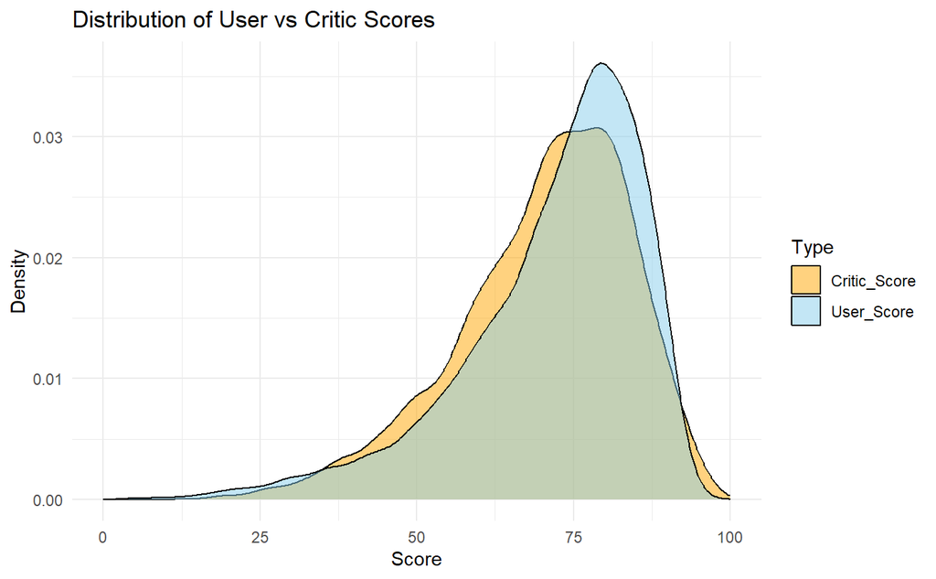

```r
long <- clean_data %>%
  select(Year_of_Release, Global_Sales, User_Score, Critic_Score) %>%
  pivot_longer(cols = c(User_Score, Critic_Score),
               names_to = "Type",
               values_to = "Score")

distribution_plot <- ggplot(long, aes(x = Score, fill = Type)) +
  geom_density(alpha = 0.5) +
  scale_x_continuous(limits = c(0, 100)) +
  labs(
    x = "Score",
    y = "Density",
    title = "Distribution of User vs Critic Scores"
  ) +
  scale_fill_manual(values = c("User_Score" = "skyblue", "Critic_Score" = "orange")) +
  theme_minimal()

ggsave("plots/distribution_plot.png", distribution_plot, width = 8.74, height = 5.11, dpi = 300)

distribution_plot


par(mfrow = c(1, 2))
```

```r
qqnorm(clean_data$User_Score, main = "QQ Plot: User Score", ylim = c(0, 100))
qqline(clean_data$User_Score, col = "red")
```

```r
qqnorm(clean_data$Critic_Score, main = "QQ Plot: Critic Score", ylim = c(0, 100))
qqline(clean_data$Critic_Score, col = "red")
```

```r
width_px  <- 8.74 * 300
height_px <- 5.11 * 300

dev.copy(png, "plots/QQplots_User_Critic.png", width = width_px, height = height_px, res = 300)
```

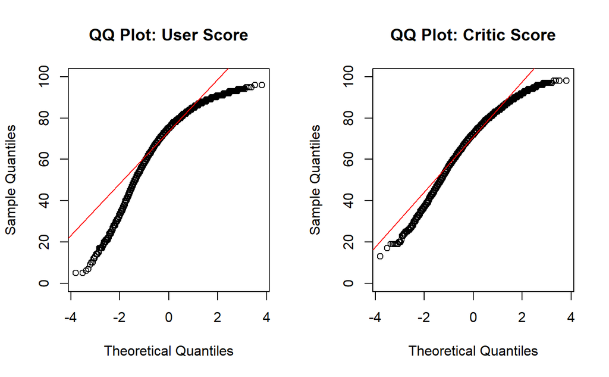

```r
dev.off()
```

## Year of Release and Global Sales

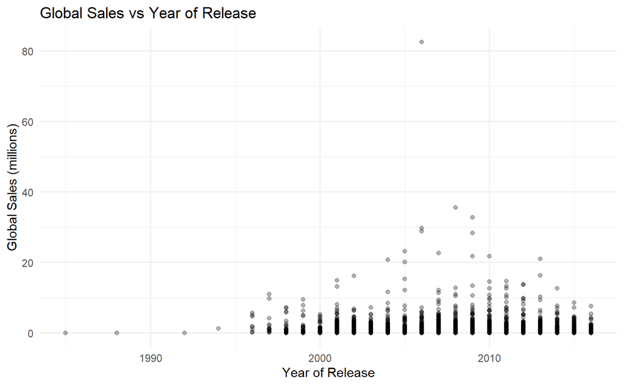

```r
sales_release_plot <- ggplot(clean_data, aes(x = Year_of_Release, y = Global_Sales)) +
  geom_point(alpha = 0.3) +
  labs(x = "Year of Release",
       y = "Global Sales (millions)",
       title = "Global Sales vs Year of Release") +
  theme_minimal()


ggsave("plots/sales_release_plot.png", sales_release_plot, width = 8.74, height = 5.11, dpi = 300)

sales_release_plot
```

Incomplete List of Games, Most Games are not on there, such as the Pc version of Minecraft missing and the list only including games up to 2016 The 2006 Outlier is Wii U Sports

## Rating per Year and Sales

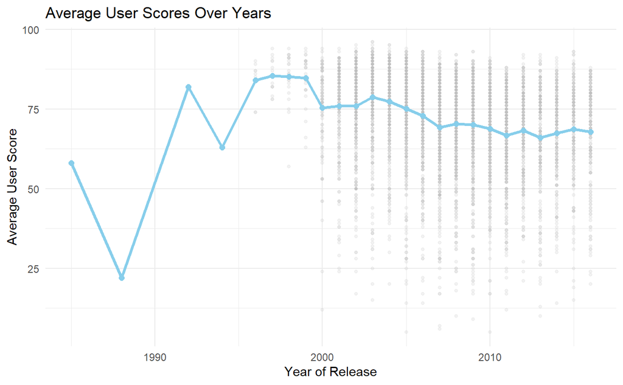

```r
# Compute average per year
avg_year <- long %>%
  group_by(Year_of_Release, Type) %>%
  summarise(mean_score = mean(Score, na.rm = TRUE))

# Filter only User_Score
long_user <- long %>% filter(Type == "User_Score")
avg_year_user <- avg_year %>% filter(Type == "User_Score")

# Plot
score_over_year_plot <- ggplot(avg_year_user, aes(x = Year_of_Release, y = mean_score)) +
  # Background scatter
  geom_point(data = long_user, aes(x = Year_of_Release, y = Score),
             alpha = 0.2, size = 1, color = "grey") +
  # Average line
  geom_line(size = 1.2, color = "skyblue") +
  geom_point(size = 2, color = "skyblue") +
  labs(x = "Year of Release",
       y = "Average User Score",
       title = "Average User Scores Over Years") +
  theme_minimal()


ggsave("plots/score_over_year_plot.png", score_over_year_plot, width = 8.74, height = 5.11, dpi = 300)

score_over_year_plot
```

## Model

$$Y = \beta_0 + \beta_1 X_1 + \beta_2 X_2 + \beta_3 X_3 + \varepsilon$$
$$\begin{align*}
where\\
Y & : \text{User Score} \\
X_1 & : \text{Critic Score} \\
X_2 & : \text{Year of Release} \\
X_3 & : \text{Global Sales} \\
\varepsilon & : \text{Random error term}
\end{align*}$$

```r
model <- lm(User_Score ~ ., data = clean_data)

summary(model)
```

[output not shown]

```r
#Getting model coefficients and P values

round(summary(model)$coefficients[, c("Estimate", "Pr(>|t|)")],4)
```

$$\[
\begin{array}{l r r}
\text{Coefficient} & \text{Estimate} & \text{p-value} \\
\hline
\text{Intercept} & 1699.0412 & 0 \\
\text{Critic\_Score} & 0.6117 & 0 \\
\text{Year\_of\_Release} & -0.8318 & 0 \\
\text{Global\_Sales} & -0.3728 & 0 \\
\end{array}
\]$$

```r
# Dont know how relevant this is
plot(model)
```

[output not shown]

## ChatGPT Analysis

This is the summary of a multiple linear regression where you model User_Score using all other variables in clean_data:

User_Score ∼ Critic_Score + Year_of_Release + Global_Sales User_Score∼Critic_Score+Year_of_Release+Global_Sales

I’ll break it down piece by piece and then interpret it in plain language.

1️⃣ Model fit (big picture) R-squared = 0.3985

About 40% of the variation in User_Score is explained by the three predictors.

This is moderate explanatory power for real-world data.

Adjusted R-squared = 0.3982

Very close to R² → adding predictors is justified.

F-statistic (p < 2.2e-16)

The model as a whole is highly statistically significant

At least one predictor meaningfully explains User_Score

Errors are centered close to 0 → good

The predicted User_Score when:

Critic_Score = 0

Year_of_Release = 0

Global_Sales = 0

Not meaningful in practice, but necessary for the model.

📈 Interpretation:

Very strong and significant predictor.

📉 Interpretation:

Suggests older games have slightly higher user scores (possible nostalgia or selection bias).

Statistically very strong.

📉 Interpretation:

Small effect, but statistically significant.

Could reflect popular games appealing to broader (not more critical) audiences.

4️⃣ Statistical significance

All predictors:

Have very low p-values

Are statistically significant at any conventional level

But ⚠️:

Statistical significance ≠ practical importance

Critic_Score matters much more than Global_Sales.

5️⃣ What this model says in plain English

User ratings are strongly aligned with critic ratings. Older games tend to receive slightly higher user scores. Higher sales are weakly associated with lower user scores. The model explains about 40% of user score variability.

6️⃣ Important caveats

Correlation ≠ causation

Year_of_Release likely captures:

changes in rating culture

survivorship bias

Global_Sales is often right-skewed → log-transform may help

clean_data$log_sales <- log1p(clean_data$Global_Sales)

## The following code and text helps cover the part of the assignment that asks to assess the Nature of randomness underlying the error terms:

```r
# Extract residuals and fitted values
residuals <- resid(model)
fitted_values <- fitted(model)
mean(residuals)
```

[output not shown]

What to put in the Presentation slides: Title:Mean of Residuals

Mean of residuals: 2.63 × 10⁻¹⁵ (≈ 0)

Numerical zero due to floating-point precision

Confirms 𝐸(𝜀)=0

Model does not systematically over- or under-predict

Supports unbiased error assumption

What to say for this slide: The mean residual is essentially zero, which confirms that the unexplained variation in the model is centered around zero. This means the model is unbiased on average.

Since the residuals are centered around zero on average, the next step is to check whether they behave randomly across the range of fitted values and whether their variance remains constant.

```r
residuals_vs_fitted_values_plot <- ggplot(data.frame(fitted_values, residuals),
       aes(x = fitted_values, y = residuals)) +
  geom_point(alpha = 0.3) +
  geom_hline(yintercept = 0, linetype = "dashed", color = "red") +
  labs(
    x = "Fitted Values",
    y = "Residuals",
    title = "Residuals vs Fitted Values"
  ) +
  theme_minimal()
ggsave("plots/residuals_vs_fitted_values.png", residuals_vs_fitted_values_plot, width = 8.74, height = 5.11, dpi = 300)
```

What to put in the Presentation slide: Title: Randomness & homoscedasticity

Residuals centered around zero

No clear nonlinear pattern

Variance decreases with fitted values

Funnel shape → heteroscedasticity

Linear trend reasonable; inference with caution

So overall, the linear structure is appropriate, but the non-constant variance should be kept in mind when interpreting the results

```r
png("plots/qqplot_residuals.png", width = 8.74 * 300, height = 5.11 * 300, res = 300 )
qqnorm(residuals, main = "QQ Plot of Residuals")
qqline(residuals, col = "red")
dev.off()
```

What to put in the Presentation slide: Title: Normality of the error terms

Assessment of normality of error terms

Residuals follow reference line closely

Mild deviations in the tails

Normality assumption approximately satisfied

Suitable for inference in large samples

Together with the mean residual and residuals vs fitted plots, this confirms that the main assumptions of the linear model are reasonably satisfied.